# Nusret Kaan Polat Homework 2 / 2018402024

2022-05-11

# Introduction

In this report, the sales of UGS for every quarter in 2007 will be forecasted by using data coming from years between 2000 and 2006 and by using time series regression models. Some analysis will be made on autocorrelation, seasonality, trend, and independent variables during the report.

```r
#install.packages("corrplot")
#install.packages("ggcorrplot")
#install.packages("GGally")
#install.packages("forecast")
#install.packages("dplyr")
#install.packages("RcppRoll")
#install.packages("readxl")
#install.packages("lubridate")
#install.packages("zoo")
#install.packages("ggplot2")
#install.packages("scales")
#install.packages("data.table")

library(corrplot)
library(ggcorrplot)
library(GGally)
library(forecast)
library(dplyr)
library(RcppRoll)
library(readxl)
library(lubridate)
library(zoo)
library(ggplot2)
library(scales)
library(data.table)
data_ugs <- read.csv("IE360_Spring22_HW2_data.csv",colClasses = c("character","numeric","numeric","numeric","numeric","numeric","numeric","numeric","numeric","numeric","numeric"))
summary(data_ugs) #look at summary of data columns
```

```
##    Quarter          Unleaded.Gasoline.Sale..UGS.      RNUV
##  Length:32          Min.   : 736580              Min.   :0.001200
##  Class :character   1st Qu.: 876210              1st Qu.:0.004100
##  Mode  :character   Median : 983573              Median :0.007250
##                     Mean   : 987212              Mean   :0.008906
##                     3rd Qu.:1097324              3rd Qu.:0.013150
##                     Max.   :1370167              Max.   :0.020700
##                     NA's   :4
##  X..LPG.Vehicles..NLPG. Price.of.Unleaded.Gasoline..PU.
##  Min.   : 940000        Min.   :402.1
##  1st Qu.: 997500        1st Qu.:479.2
##  Median :1352000        Median :526.7
##  Mean   :1299922        Mean   :519.2
##  3rd Qu.:1602000        3rd Qu.:565.2
##  Max.   :1797400        Max.   :609.0
##
##  Price.of.Diesel.Gasoline..PG. X..Unleaded.Gasoline.Vehicles..NUGV.
##  Min.   :300.7                 Min.   :4647500
##  1st Qu.:366.9                 1st Qu.:5029281
##  Median :401.6                 Median :5186068
##  Mean   :400.4                 Mean   :5296758
##  3rd Qu.:449.2                 3rd Qu.:5604709
##  Max.   :471.9                 Max.   :6065597
##
##  X..of.Diesel.Gasoline.Vehicles..NDGV. GNP.Agriculture    GNP.Commerce
##  Min.   :282.0                         Min.   : 832953   Min.   :3374849
##  1st Qu.:286.6                         1st Qu.:1348066   1st Qu.:4403081
##  Median :291.9                         Median :1850657   Median :5124300
##  Mean   :304.9                         Mean   :2895561   Mean   :5246534
##  3rd Qu.:322.9                         3rd Qu.:3922950   3rd Qu.:5967433
##  Max.   :357.3                         Max.   :7140722   Max.   :7480414
##
##    GNP.Total
##  Min.   :15832648
##  1st Qu.:21790148
##  Median :25229712
##  Mean   :25745763
##  3rd Qu.:29843404
##  Max.   :36741745
##
```

```r
str(data_ugs) #control of columns types etc.
```

```
## 'data.frame':    32 obs. of  11 variables:
##  $ Quarter                              : chr  "2000_Q1" "2000_Q2" "2000_Q3" "2000_Q4" ...
##  $ Unleaded.Gasoline.Sale..UGS.         : num  1128971 1199569 1370167 1127548 1033918 ...
##  $ RNUV                                 : num  0.0146 0.0205 0.0207 0.0163 0.0071 0.0051 0.0041 0.0048 0.0012 0.0032 ...
##  $ X..LPG.Vehicles..NLPG.               : num  940000 941000 943500 948000 950000 ...
##  $ Price.of.Unleaded.Gasoline..PU.      : num  469 459 440 402 412 ...
##  $ Price.of.Diesel.Gasoline..PG.        : num  356 345 327 301 306 ...
##  $ X..Unleaded.Gasoline.Vehicles..NUGV. : num  4647500 4742876 4840931 4919685 4954754 ...
##  $ X..of.Diesel.Gasoline.Vehicles..NDGV.: num  282 284 287 288 288 ...
##  $ GNP.Agriculture                      : num  1040173 1760460 6974808 3267125 1004528 ...
##  $ GNP.Commerce                         : num  3483132 4525451 5915204 4929778 3418387 ...
##  $ GNP.Total                            : num  18022686 21797130 30050207 24480153 15832648 ...
```

```r
head(data_ugs,n = 5) # look at first 5 elements in the data we have
```

```
##   Quarter Unleaded.Gasoline.Sale..UGS.   RNUV X..LPG.Vehicles..NLPG.
## 1 2000_Q1                      1128971 0.0146                 940000
## 2 2000_Q2                      1199569 0.0205                 941000
## 3 2000_Q3                      1370167 0.0207                 943500
## 4 2000_Q4                      1127548 0.0163                 948000
## 5 2001_Q1                      1033918 0.0071                 950000
##   Price.of.Unleaded.Gasoline..PU. Price.of.Diesel.Gasoline..PG.
## 1                          469.03                        355.69
## 2                          459.42                        344.58
## 3                          439.98                        327.21
## 4                          402.08                        300.67
## 5                          411.58                        305.75
##   X..Unleaded.Gasoline.Vehicles..NUGV. X..of.Diesel.Gasoline.Vehicles..NDGV.
## 1                              4647500                              281.9853
## 2                              4742876                              284.0813
## 3                              4840931                              286.7169
## 4                              4919685                              288.3137
## 5                              4954754                              287.6237
##   GNP.Agriculture GNP.Commerce GNP.Total
## 1         1040173      3483132  18022686
## 2         1760460      4525451  21797130
## 3         6974808      5915204  30050207
## 4         3267125      4929778  24480153
## 5         1004528      3418387  15832648
```

```r
data_ugs$Quarter=as.Date(as.yearqtr(data_ugs$Quarter,format="%Y_Q%q"))
data_ugs_training <- data.table(data_ugs[1:28,])
data_ugs_to_be_forecasted <- data.table(data_ugs[-(1:28),])
str(data_ugs_training)
```

```
## Classes 'data.table' and 'data.frame':   28 obs. of  11 variables:
##  $ Quarter                              : Date, format: "2000-01-01" "2000-04-01" ...
##  $ Unleaded.Gasoline.Sale..UGS.         : num  1128971 1199569 1370167 1127548 1033918 ...
##  $ RNUV                                 : num  0.0146 0.0205 0.0207 0.0163 0.0071 0.0051 0.0041 0.0048 0.0012 0.0032 ...
##  $ X..LPG.Vehicles..NLPG.               : num  940000 941000 943500 948000 950000 ...
##  $ Price.of.Unleaded.Gasoline..PU.      : num  469 459 440 402 412 ...
##  $ Price.of.Diesel.Gasoline..PG.        : num  356 345 327 301 306 ...
##  $ X..Unleaded.Gasoline.Vehicles..NUGV. : num  4647500 4742876 4840931 4919685 4954754 ...
##  $ X..of.Diesel.Gasoline.Vehicles..NDGV.: num  282 284 287 288 288 ...
##  $ GNP.Agriculture                      : num  1040173 1760460 6974808 3267125 1004528 ...
##  $ GNP.Commerce                         : num  3483132 4525451 5915204 4929778 3418387 ...
##  $ GNP.Total                            : num  18022686 21797130 30050207 24480153 15832648 ...
##  - attr(*, ".internal.selfref")=<externalptr>
```

```r
str(data_ugs_to_be_forecasted)
```

```
## Classes 'data.table' and 'data.frame':   4 obs. of  11 variables:
##  $ Quarter                              : Date, format: "2007-01-01" "2007-04-01" ...
##  $ Unleaded.Gasoline.Sale..UGS.         : num  NA NA NA NA
##  $ RNUV                                 : num  0.0074 0.0106 0.0101 0.0124
##  $ X..LPG.Vehicles..NLPG.               : num  1715000 1725300 1751050 1797400
##  $ Price.of.Unleaded.Gasoline..PU.      : num  565 565 565 565
##  $ Price.of.Diesel.Gasoline..PG.        : num  449 449 449 449
##  $ X..Unleaded.Gasoline.Vehicles..NUGV. : num  5869018 5931348 5991280 6065597
##  $ X..of.Diesel.Gasoline.Vehicles..NDGV.: num  342 347 351 357
##  $ GNP.Agriculture                      : num  1132973 1570703 7140722 2418541
##  $ GNP.Commerce                         : num  4857305 5852404 7480414 6397745
##  $ GNP.Total                            : num  24413807 27597857 36741745 31361112
##  - attr(*, ".internal.selfref")=<externalptr>
```

## Analysis on Initial Data

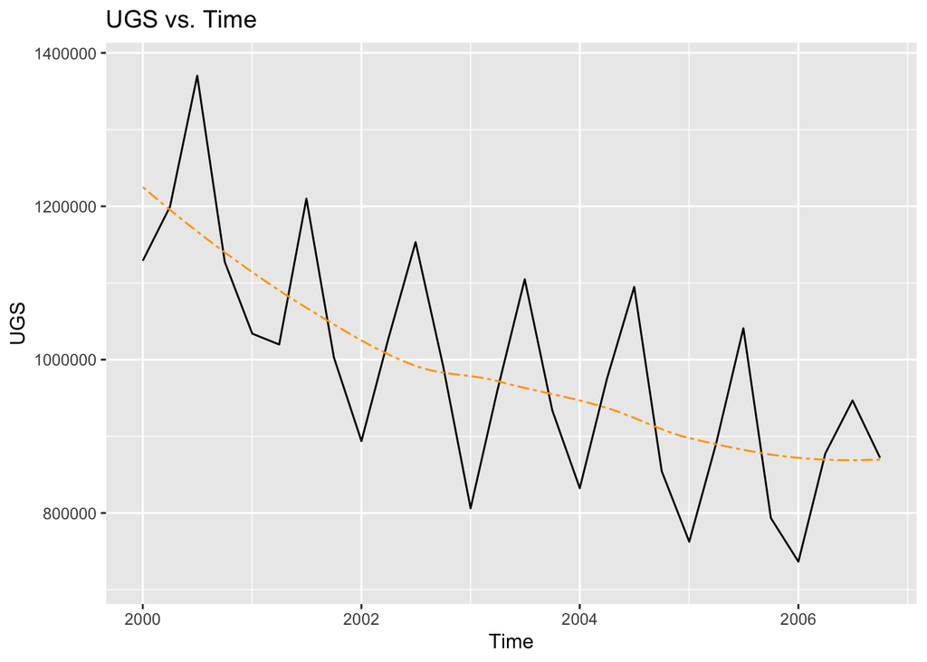

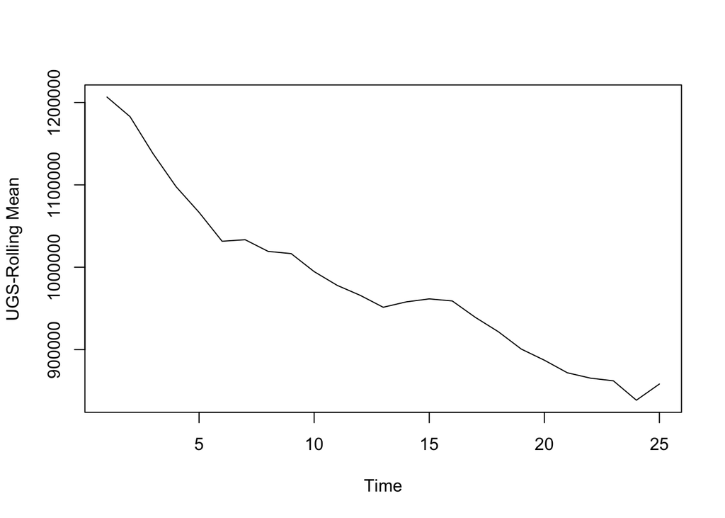

[figure not shown]

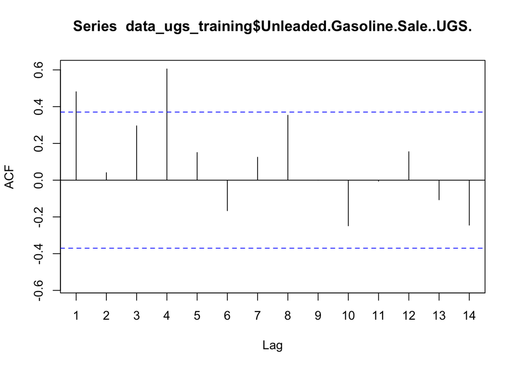

```r
Acf(data_ugs_training$Unleaded.Gasoline.Sale..UGS.)
```

## ACF Analysis

When we look at autocorrelation plot, it can be seen that there are high correlation values exceeding threshold shown as blue line. These values are for lag 1 and lag 4. High value in lag 4 means that the same quarter for the different years shows somehow related and similar behavior. On the other hand, lag 1 is coming from the overall tendency in the data. Because data has overall behavior over time, namely trend, this causes high correlation at lag 1.

## Start with the first step

There is an obvious trend and seasonality in the data coming from analysis we made in the previos sections. So including new columns explaining this trend and seasonality may result in high accuracy in predictions in case we build a model.

```r
data_ugs_training$Trend <- 1:nrow(data_ugs_training)
data_ugs_to_be_forecasted$Trend <-c(29,30,31,32)
#data_ugs_training$QuarterInfo <- rep(x = c(1,2,3,4),7)
data_ugs_training$QuarterInfo <- as.factor(quarter(data_ugs_training$Quarter))
data_ugs_to_be_forecasted$QuarterInfo  <- as.factor(quarter(data_ugs_to_be_forecasted$Quarter))
str(data_ugs_training)
```

```
## Classes 'data.table' and 'data.frame':   28 obs. of  13 variables:
##  $ Quarter                              : Date, format: "2000-01-01" "2000-04-01" ...
##  $ Unleaded.Gasoline.Sale..UGS.         : num  1128971 1199569 1370167 1127548 1033918 ...
##  $ RNUV                                 : num  0.0146 0.0205 0.0207 0.0163 0.0071 0.0051 0.0041 0.0048 0.0012 0.0032 ...
##  $ X..LPG.Vehicles..NLPG.               : num  940000 941000 943500 948000 950000 ...
##  $ Price.of.Unleaded.Gasoline..PU.      : num  469 459 440 402 412 ...
##  $ Price.of.Diesel.Gasoline..PG.        : num  356 345 327 301 306 ...
##  $ X..Unleaded.Gasoline.Vehicles..NUGV. : num  4647500 4742876 4840931 4919685 4954754 ...
##  $ X..of.Diesel.Gasoline.Vehicles..NDGV.: num  282 284 287 288 288 ...
##  $ GNP.Agriculture                      : num  1040173 1760460 6974808 3267125 1004528 ...
##  $ GNP.Commerce                         : num  3483132 4525451 5915204 4929778 3418387 ...
##  $ GNP.Total                            : num  18022686 21797130 30050207 24480153 15832648 ...
##  $ Trend                                : int  1 2 3 4 5 6 7 8 9 10 ...
##  $ QuarterInfo                          : Factor w/ 4 levels "1","2","3","4": 1 2 3 4 1 2 3 4 1 2 ...
##  - attr(*, ".internal.selfref")=<externalptr>
```

```r
str(data_ugs_to_be_forecasted) # to check added columns etc.
```

```
## Classes 'data.table' and 'data.frame':   4 obs. of  13 variables:
##  $ Quarter                              : Date, format: "2007-01-01" "2007-04-01" ...
##  $ Unleaded.Gasoline.Sale..UGS.         : num  NA NA NA NA
##  $ RNUV                                 : num  0.0074 0.0106 0.0101 0.0124
##  $ X..LPG.Vehicles..NLPG.               : num  1715000 1725300 1751050 1797400
##  $ Price.of.Unleaded.Gasoline..PU.      : num  565 565 565 565
##  $ Price.of.Diesel.Gasoline..PG.        : num  449 449 449 449
##  $ X..Unleaded.Gasoline.Vehicles..NUGV. : num  5869018 5931348 5991280 6065597
##  $ X..of.Diesel.Gasoline.Vehicles..NDGV.: num  342 347 351 357
##  $ GNP.Agriculture                      : num  1132973 1570703 7140722 2418541
##  $ GNP.Commerce                         : num  4857305 5852404 7480414 6397745
##  $ GNP.Total                            : num  24413807 27597857 36741745 31361112
##  $ Trend                                : num  29 30 31 32
##  $ QuarterInfo                          : Factor w/ 4 levels "1","2","3","4": 1 2 3 4
##  - attr(*, ".internal.selfref")=<externalptr>
```

```r
initial_model <- lm(Unleaded.Gasoline.Sale..UGS.~ Trend+QuarterInfo, data_ugs_training)
summary(initial_model)
```

```
##
## Call:
## lm(formula = Unleaded.Gasoline.Sale..UGS. ~ Trend + QuarterInfo,
##     data = data_ugs_training)
##
## Residuals:
##    Min     1Q Median     3Q    Max
## -81167 -31283  -3458  28640  94502
##
## Coefficients:
##              Estimate Std. Error t value Pr(>|t|)
## (Intercept)   1060372      23653  44.830  < 2e-16 ***
## Trend          -13497       1147 -11.764 3.28e-11 ***
## QuarterInfo2   121532      25987   4.677 0.000104 ***
## QuarterInfo3   273618      26063  10.498 3.03e-10 ***
## QuarterInfo4    95049      26189   3.629 0.001405 **
## ---
## Signif. codes:  0 '***' 0.001 '**' 0.01 '*' 0.05 '.' 0.1 ' ' 1
##
## Residual standard error: 48570 on 23 degrees of freedom
## Multiple R-squared:  0.9119, Adjusted R-squared:  0.8966
## F-statistic: 59.53 on 4 and 23 DF,  p-value: 8.446e-12
```

## Comments on first model created

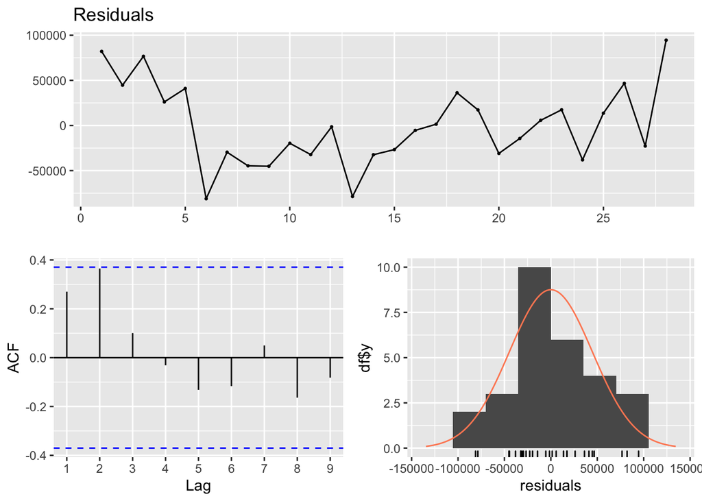

```r
checkresiduals(initial_model$residuals)
```

```r
initial_model <- lm(Unleaded.Gasoline.Sale..UGS.~ Trend+QuarterInfo, data_ugs_training)
summary(initial_model)
```

```
##
## Call:
## lm(formula = Unleaded.Gasoline.Sale..UGS. ~ Trend + QuarterInfo,
##     data = data_ugs_training)
##
## Residuals:
##    Min     1Q Median     3Q    Max
## -81167 -31283  -3458  28640  94502
##
## Coefficients:
##              Estimate Std. Error t value Pr(>|t|)
## (Intercept)   1060372      23653  44.830  < 2e-16 ***
## Trend          -13497       1147 -11.764 3.28e-11 ***
## QuarterInfo2   121532      25987   4.677 0.000104 ***
## QuarterInfo3   273618      26063  10.498 3.03e-10 ***
## QuarterInfo4    95049      26189   3.629 0.001405 **
## ---
## Signif. codes:  0 '***' 0.001 '**' 0.01 '*' 0.05 '.' 0.1 ' ' 1
##
## Residual standard error: 48570 on 23 degrees of freedom
## Multiple R-squared:  0.9119, Adjusted R-squared:  0.8966
## F-statistic: 59.53 on 4 and 23 DF,  p-value: 8.446e-12
```

```r
data_ugs_training$Lag2=lag(data_ugs_training$Unleaded.Gasoline.Sale..UGS.,2)
second_model <- lm(Unleaded.Gasoline.Sale..UGS.~ Trend+QuarterInfo+Lag2, data_ugs_training)
summary(second_model)
```

```
##
## Call:
## lm(formula = Unleaded.Gasoline.Sale..UGS. ~ Trend + QuarterInfo +
##     Lag2, data = data_ugs_training)
##
## Residuals:
##    Min     1Q Median     3Q    Max
## -78490 -25706  10316  20897  55505
##
## Coefficients:
##                Estimate Std. Error t value Pr(>|t|)
## (Intercept)   3.617e+05  2.673e+05   1.354   0.1910
## Trend        -5.401e+03  2.940e+03  -1.837   0.0811 .
## QuarterInfo2  2.223e+05  4.466e+04   4.977 7.25e-05 ***
## QuarterInfo3  4.218e+05  5.814e+04   7.255 5.10e-07 ***
## QuarterInfo4  1.828e+05  3.739e+04   4.888 8.90e-05 ***
## Lag2          4.848e-01  1.937e-01   2.504   0.0211 *
## ---
## Signif. codes:  0 '***' 0.001 '**' 0.01 '*' 0.05 '.' 0.1 ' ' 1
##
## Residual standard error: 39940 on 20 degrees of freedom
##   (2 observations deleted due to missingness)
## Multiple R-squared:  0.9416, Adjusted R-squared:  0.9269
## F-statistic: 64.44 on 5 and 20 DF,  p-value: 1.215e-11
```

## Comments on addition of Lag2 and Correlation Matrix

When we added Lag2 to the model, the adj-R squared value is increased but lag 2 is not so significant variable so I try to use other regressors firstly then if needed we will again consider lags. To be able to see which regressors are important it is logical to plot correlation matrix. Then we need to search for which regressors are highly correlated with UGS. When we look at the matrix, it can be seen that there are variables such as X..LPG.Vehicles..NLPG./ Price.of.Unleaded.Gasoline..PU. / Price.of.Diesel.Gasoline..PG./ X..Unleaded.Gasoline.Vehicles..NUGV. /X..of.Diesel.Gasoline.Vehicles..NDGV. / GNP.Agriculture / having significant values other than QuarterInfo and Trend that were already determined to be added to the model.

```r
data_ugs_training<-select(data_ugs_training,-Lag2)
```

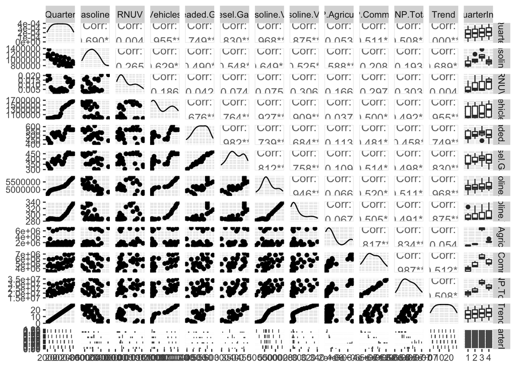

```r
ggpairs(data_ugs_training,warning=FALSE,message=FALSE)
```

## The New Model That Considers Seasonality, Trend, and Other Independent Regressors When the new model is analyzed, it can be seen that adj-R squared is increased to 0.9613. However, there are some insignificant variables, which may be rooted from the resaon that one variables may already explain the information coming from the other. Therefore, maybe these unsignificant variables may cause lower adjusted square because of loss of degree of freedom. So, I want to try to exclude some unsignificant variables. By excluding each of unsignificant variables one by one, I created new model and one of these models has greater adjusted R square value 0.9635 than the model including all regressors which we determined at the start. “Price.of.Unleaded.Gasoline..PU.” variable is excluded.

```r
Improved_Model <- lm(Unleaded.Gasoline.Sale..UGS.~ Trend+QuarterInfo+X..LPG.Vehicles..NLPG. + Price.of.Unleaded.Gasoline..PU. + Price.of.Diesel.Gasoline..PG.+ X..Unleaded.Gasoline.Vehicles..NUGV. + X..of.Diesel.Gasoline.Vehicles..NDGV. + GNP.Agriculture , data_ugs_training)
summary(Improved_Model)
```

```
##
## Call:
## lm(formula = Unleaded.Gasoline.Sale..UGS. ~ Trend + QuarterInfo +
##     X..LPG.Vehicles..NLPG. + Price.of.Unleaded.Gasoline..PU. +
##     Price.of.Diesel.Gasoline..PG. + X..Unleaded.Gasoline.Vehicles..NUGV. +
##     X..of.Diesel.Gasoline.Vehicles..NDGV. + GNP.Agriculture,
##     data = data_ugs_training)
##
## Residuals:
##    Min     1Q Median     3Q    Max
## -67794 -10461   1987  18461  32208
##
## Coefficients:
##                                         Estimate Std. Error t value Pr(>|t|)
## (Intercept)                            3.094e+06  8.283e+05   3.735  0.00165
## Trend                                  1.514e+04  1.284e+04   1.178  0.25486
## QuarterInfo2                           1.463e+05  2.356e+04   6.212 9.48e-06
## QuarterInfo3                           4.953e+05  1.597e+05   3.102  0.00648
## QuarterInfo4                           1.607e+05  4.385e+04   3.664  0.00192
## X..LPG.Vehicles..NLPG.                -2.937e-01  1.804e-01  -1.628  0.12195
## Price.of.Unleaded.Gasoline..PU.        2.276e+01  1.017e+03   0.022  0.98241
## Price.of.Diesel.Gasoline..PG.         -1.129e+03  1.437e+03  -0.786  0.44295
## X..Unleaded.Gasoline.Vehicles..NUGV.  -1.023e+00  3.343e-01  -3.061  0.00708
## X..of.Diesel.Gasoline.Vehicles..NDGV.  1.238e+04  3.581e+03   3.456  0.00302
## GNP.Agriculture                       -3.613e-02  2.764e-02  -1.307  0.20854
##
## (Intercept)                           **
## Trend
## QuarterInfo2                          ***
## QuarterInfo3                          **
## QuarterInfo4                          **
## X..LPG.Vehicles..NLPG.
## Price.of.Unleaded.Gasoline..PU.
## Price.of.Diesel.Gasoline..PG.
## X..Unleaded.Gasoline.Vehicles..NUGV.  **
## X..of.Diesel.Gasoline.Vehicles..NDGV. **
## GNP.Agriculture
## ---
## Signif. codes:  0 '***' 0.001 '**' 0.01 '*' 0.05 '.' 0.1 ' ' 1
##
## Residual standard error: 29700 on 17 degrees of freedom
## Multiple R-squared:  0.9757, Adjusted R-squared:  0.9613
## F-statistic: 68.12 on 10 and 17 DF,  p-value: 1.055e-11
```

```r
Improved_Model2 <- lm(Unleaded.Gasoline.Sale..UGS.~ Trend+QuarterInfo+Price.of.Unleaded.Gasoline..PU.+ Price.of.Diesel.Gasoline..PG.+ X..Unleaded.Gasoline.Vehicles..NUGV. + X..of.Diesel.Gasoline.Vehicles..NDGV. + GNP.Agriculture , data_ugs_training)
summary(Improved_Model2)
```

```
##
## Call:
## lm(formula = Unleaded.Gasoline.Sale..UGS. ~ Trend + QuarterInfo +
##     Price.of.Unleaded.Gasoline..PU. + Price.of.Diesel.Gasoline..PG. +
##     X..Unleaded.Gasoline.Vehicles..NUGV. + X..of.Diesel.Gasoline.Vehicles..NDGV. +
##     GNP.Agriculture, data = data_ugs_training)
##
## Residuals:
##    Min     1Q Median     3Q    Max
## -60059 -13083  -1138  15485  52996
##
## Coefficients:
##                                         Estimate Std. Error t value Pr(>|t|)
## (Intercept)                            1.973e+06  4.812e+05   4.100 0.000672
## Trend                                 -4.500e+03  4.609e+03  -0.976 0.341787
## QuarterInfo2                           1.465e+05  2.462e+04   5.952 1.24e-05
## QuarterInfo3                           4.164e+05  1.590e+05   2.619 0.017377
## QuarterInfo4                           1.339e+05  4.247e+04   3.153 0.005501
## Price.of.Unleaded.Gasoline..PU.       -8.365e+02  9.086e+02  -0.921 0.369387
## Price.of.Diesel.Gasoline..PG.          3.007e+02  1.188e+03   0.253 0.803062
## X..Unleaded.Gasoline.Vehicles..NUGV.  -5.432e-01  1.645e-01  -3.301 0.003971
## X..of.Diesel.Gasoline.Vehicles..NDGV.  7.048e+03  1.517e+03   4.645 0.000201
## GNP.Agriculture                       -2.206e-02  2.743e-02  -0.804 0.431693
##
## (Intercept)                           ***
## Trend
## QuarterInfo2                          ***
## QuarterInfo3                          *
## QuarterInfo4                          **
## Price.of.Unleaded.Gasoline..PU.
## Price.of.Diesel.Gasoline..PG.
## X..Unleaded.Gasoline.Vehicles..NUGV.  **
## X..of.Diesel.Gasoline.Vehicles..NDGV. ***
## GNP.Agriculture
## ---
## Signif. codes:  0 '***' 0.001 '**' 0.01 '*' 0.05 '.' 0.1 ' ' 1
##
## Residual standard error: 31030 on 18 degrees of freedom
## Multiple R-squared:  0.9719, Adjusted R-squared:  0.9578
## F-statistic: 69.06 on 9 and 18 DF,  p-value: 4.105e-12
```

```r
Improved_Model3 <- lm(Unleaded.Gasoline.Sale..UGS.~ Trend+QuarterInfo+X..LPG.Vehicles..NLPG. +  Price.of.Diesel.Gasoline..PG.+ X..Unleaded.Gasoline.Vehicles..NUGV. + X..of.Diesel.Gasoline.Vehicles..NDGV. + GNP.Agriculture , data_ugs_training)
summary(Improved_Model3)
```

```
##
## Call:
## lm(formula = Unleaded.Gasoline.Sale..UGS. ~ Trend + QuarterInfo +
##     X..LPG.Vehicles..NLPG. + Price.of.Diesel.Gasoline..PG. +
##     X..Unleaded.Gasoline.Vehicles..NUGV. + X..of.Diesel.Gasoline.Vehicles..NDGV. +
##     GNP.Agriculture, data = data_ugs_training)
##
## Residuals:
##    Min     1Q Median     3Q    Max
## -67784 -10477   1910  18384  32378
##
## Coefficients:
##                                         Estimate Std. Error t value Pr(>|t|)
## (Intercept)                            3.084e+06  6.773e+05   4.553 0.000247
## Trend                                  1.495e+04  9.639e+03   1.551 0.138240
## QuarterInfo2                           1.465e+05  2.199e+04   6.662 2.99e-06
## QuarterInfo3                           4.952e+05  1.550e+05   3.194 0.005027
## QuarterInfo4                           1.606e+05  4.223e+04   3.802 0.001306
## X..LPG.Vehicles..NLPG.                -2.916e-01  1.499e-01  -1.945 0.067504
## Price.of.Diesel.Gasoline..PG.         -1.097e+03  3.116e+02  -3.522 0.002437
## X..Unleaded.Gasoline.Vehicles..NUGV.  -1.019e+00  2.602e-01  -3.915 0.001015
## X..of.Diesel.Gasoline.Vehicles..NDGV.  1.233e+04  2.826e+03   4.362 0.000375
## GNP.Agriculture                       -3.610e-02  2.682e-02  -1.346 0.194993
##
## (Intercept)                           ***
## Trend
## QuarterInfo2                          ***
## QuarterInfo3                          **
## QuarterInfo4                          **
## X..LPG.Vehicles..NLPG.                .
## Price.of.Diesel.Gasoline..PG.         **
## X..Unleaded.Gasoline.Vehicles..NUGV.  **
## X..of.Diesel.Gasoline.Vehicles..NDGV. ***
## GNP.Agriculture
## ---
## Signif. codes:  0 '***' 0.001 '**' 0.01 '*' 0.05 '.' 0.1 ' ' 1
##
## Residual standard error: 28870 on 18 degrees of freedom
## Multiple R-squared:  0.9757, Adjusted R-squared:  0.9635
## F-statistic: 80.14 on 9 and 18 DF,  p-value: 1.128e-12
```

```r
Improved_Model4 <- lm(Unleaded.Gasoline.Sale..UGS.~ Trend+QuarterInfo+X..LPG.Vehicles..NLPG. + Price.of.Unleaded.Gasoline..PU. + X..Unleaded.Gasoline.Vehicles..NUGV. + X..of.Diesel.Gasoline.Vehicles..NDGV. + GNP.Agriculture , data_ugs_training)
summary(Improved_Model4)
```

```
##
## Call:
## lm(formula = Unleaded.Gasoline.Sale..UGS. ~ Trend + QuarterInfo +
##     X..LPG.Vehicles..NLPG. + Price.of.Unleaded.Gasoline..PU. +
##     X..Unleaded.Gasoline.Vehicles..NUGV. + X..of.Diesel.Gasoline.Vehicles..NDGV. +
##     GNP.Agriculture, data = data_ugs_training)
##
## Residuals:
##    Min     1Q Median     3Q    Max
## -66562  -8231   -274  16957  39535
##
## Coefficients:
##                                         Estimate Std. Error t value Pr(>|t|)
## (Intercept)                            2.677e+06  6.293e+05   4.254 0.000477
## Trend                                  7.740e+03  8.644e+03   0.895 0.382353
## QuarterInfo2                           1.496e+05  2.295e+04   6.516 3.99e-06
## QuarterInfo3                           4.720e+05  1.552e+05   3.041 0.007030
## QuarterInfo4                           1.518e+05  4.190e+04   3.622 0.001949
## X..LPG.Vehicles..NLPG.                -2.071e-01  1.413e-01  -1.466 0.159965
## Price.of.Unleaded.Gasoline..PU.       -7.562e+02  2.246e+02  -3.367 0.003432
## X..Unleaded.Gasoline.Vehicles..NUGV.  -8.425e-01  2.400e-01  -3.511 0.002496
## X..of.Diesel.Gasoline.Vehicles..NDGV.  1.046e+04  2.590e+03   4.037 0.000773
## GNP.Agriculture                       -3.187e-02  2.681e-02  -1.189 0.250013
##
## (Intercept)                           ***
## Trend
## QuarterInfo2                          ***
## QuarterInfo3                          **
## QuarterInfo4                          **
## X..LPG.Vehicles..NLPG.
## Price.of.Unleaded.Gasoline..PU.       **
## X..Unleaded.Gasoline.Vehicles..NUGV.  **
## X..of.Diesel.Gasoline.Vehicles..NDGV. ***
## GNP.Agriculture
## ---
## Signif. codes:  0 '***' 0.001 '**' 0.01 '*' 0.05 '.' 0.1 ' ' 1
##
## Residual standard error: 29380 on 18 degrees of freedom
## Multiple R-squared:  0.9748, Adjusted R-squared:  0.9622
## F-statistic: 77.26 on 9 and 18 DF,  p-value: 1.551e-12
```

```r
Improved_Model5 <- lm(Unleaded.Gasoline.Sale..UGS.~ Trend+QuarterInfo+X..LPG.Vehicles..NLPG. + Price.of.Unleaded.Gasoline..PU. + Price.of.Diesel.Gasoline..PG.+ X..Unleaded.Gasoline.Vehicles..NUGV. + X..of.Diesel.Gasoline.Vehicles..NDGV. , data_ugs_training)
summary(Improved_Model5)
```

```
##
## Call:
## lm(formula = Unleaded.Gasoline.Sale..UGS. ~ Trend + QuarterInfo +
##     X..LPG.Vehicles..NLPG. + Price.of.Unleaded.Gasoline..PU. +
##     Price.of.Diesel.Gasoline..PG. + X..Unleaded.Gasoline.Vehicles..NUGV. +
##     X..of.Diesel.Gasoline.Vehicles..NDGV., data = data_ugs_training)
##
## Residuals:
##    Min     1Q Median     3Q    Max
## -67603 -15388   -755  17814  41463
##
## Coefficients:
##                                         Estimate Std. Error t value Pr(>|t|)
## (Intercept)                            2.603e+06  7.527e+05   3.458  0.00280
## Trend                                  8.528e+03  1.204e+04   0.708  0.48773
## QuarterInfo2                           1.260e+05  1.804e+04   6.985 1.60e-06
## QuarterInfo3                           2.877e+05  1.675e+04  17.176 1.31e-12
## QuarterInfo4                           1.080e+05  1.752e+04   6.161 8.12e-06
## X..LPG.Vehicles..NLPG.                -2.199e-01  1.747e-01  -1.259  0.22415
## Price.of.Unleaded.Gasoline..PU.       -5.450e+01  1.035e+03  -0.053  0.95860
## Price.of.Diesel.Gasoline..PG.         -7.600e+02  1.436e+03  -0.529  0.60313
## X..Unleaded.Gasoline.Vehicles..NUGV.  -8.340e-01  3.073e-01  -2.714  0.01421
## X..of.Diesel.Gasoline.Vehicles..NDGV.  1.027e+04  3.261e+03   3.150  0.00554
##
## (Intercept)                           **
## Trend
## QuarterInfo2                          ***
## QuarterInfo3                          ***
## QuarterInfo4                          ***
## X..LPG.Vehicles..NLPG.
## Price.of.Unleaded.Gasoline..PU.
## Price.of.Diesel.Gasoline..PG.
## X..Unleaded.Gasoline.Vehicles..NUGV.  *
## X..of.Diesel.Gasoline.Vehicles..NDGV. **
## ---
## Signif. codes:  0 '***' 0.001 '**' 0.01 '*' 0.05 '.' 0.1 ' ' 1
##
## Residual standard error: 30280 on 18 degrees of freedom
## Multiple R-squared:  0.9732, Adjusted R-squared:  0.9598
## F-statistic: 72.64 on 9 and 18 DF,  p-value: 2.651e-12
```

## Checking Residuals After Adding Regressors

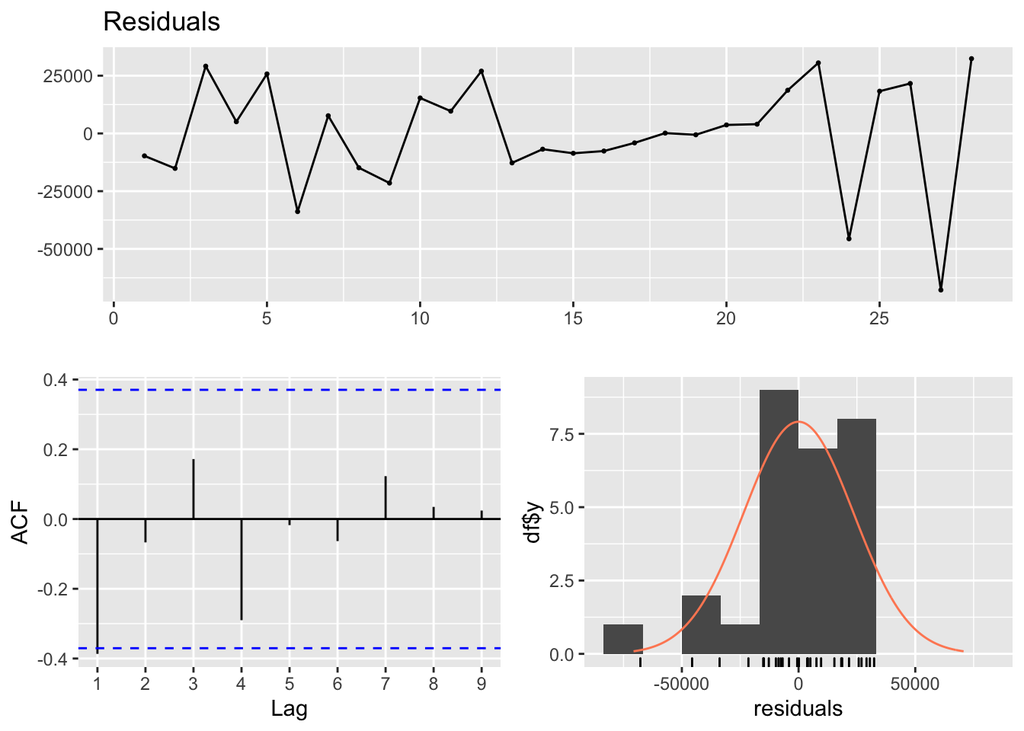

```r
checkresiduals(Improved_Model3$residuals,warning=FALSE,message=FALSE)
```

```r
data_ugs_training$Lag1=lag(data_ugs_training$Unleaded.Gasoline.Sale..UGS.,1)

Improved_Model6 <-  lm(Unleaded.Gasoline.Sale..UGS.~ Trend+QuarterInfo+X..LPG.Vehicles..NLPG. +  Lag1 +Price.of.Diesel.Gasoline..PG.+ X..Unleaded.Gasoline.Vehicles..NUGV. + X..of.Diesel.Gasoline.Vehicles..NDGV. + GNP.Agriculture , data_ugs_training)
summary(Improved_Model6)
```

```
##
## Call:
## lm(formula = Unleaded.Gasoline.Sale..UGS. ~ Trend + QuarterInfo +
##     X..LPG.Vehicles..NLPG. + Lag1 + Price.of.Diesel.Gasoline..PG. +
##     X..Unleaded.Gasoline.Vehicles..NUGV. + X..of.Diesel.Gasoline.Vehicles..NDGV. +
##     GNP.Agriculture, data = data_ugs_training)
##
## Residuals:
##    Min     1Q Median     3Q    Max
## -50749 -14170   1398  15401  36065
##
## Coefficients:
##                                         Estimate Std. Error t value Pr(>|t|)
## (Intercept)                            3.888e+06  8.898e+05   4.369 0.000477
## Trend                                  1.083e+04  1.214e+04   0.892 0.385546
## QuarterInfo2                           8.997e+04  3.627e+04   2.480 0.024629
## QuarterInfo3                           3.655e+05  1.803e+05   2.027 0.059626
## QuarterInfo4                           2.083e+05  4.716e+04   4.417 0.000432
## X..LPG.Vehicles..NLPG.                -2.796e-01  1.654e-01  -1.691 0.110292
## Lag1                                  -4.335e-01  2.299e-01  -1.886 0.077610
## Price.of.Diesel.Gasoline..PG.         -1.017e+03  3.069e+02  -3.314 0.004388
## X..Unleaded.Gasoline.Vehicles..NUGV.  -1.249e+00  3.523e-01  -3.545 0.002693
## X..of.Diesel.Gasoline.Vehicles..NDGV.  1.502e+04  3.735e+03   4.021 0.000987
## GNP.Agriculture                       -1.105e-02  3.240e-02  -0.341 0.737609
##
## (Intercept)                           ***
## Trend
## QuarterInfo2                          *
## QuarterInfo3                          .
## QuarterInfo4                          ***
## X..LPG.Vehicles..NLPG.
## Lag1                                  .
## Price.of.Diesel.Gasoline..PG.         **
## X..Unleaded.Gasoline.Vehicles..NUGV.  **
## X..of.Diesel.Gasoline.Vehicles..NDGV. ***
## GNP.Agriculture
## ---
## Signif. codes:  0 '***' 0.001 '**' 0.01 '*' 0.05 '.' 0.1 ' ' 1
##
## Residual standard error: 27400 on 16 degrees of freedom
##   (1 observation deleted due to missingness)
## Multiple R-squared:  0.9798, Adjusted R-squared:  0.9672
## F-statistic: 77.68 on 10 and 16 DF,  p-value: 1.267e-11
```

```r
data_ugs_training$Lag4=lag(data_ugs_training$Unleaded.Gasoline.Sale..UGS.,4)

Improved_Model7 <- lm(Unleaded.Gasoline.Sale..UGS.~ Lag4+Lag1+Trend+QuarterInfo+X..LPG.Vehicles..NLPG. +  Price.of.Diesel.Gasoline..PG.+ X..Unleaded.Gasoline.Vehicles..NUGV. + X..of.Diesel.Gasoline.Vehicles..NDGV. + GNP.Agriculture , data_ugs_training)
summary(Improved_Model7)
```

```
##
## Call:
## lm(formula = Unleaded.Gasoline.Sale..UGS. ~ Lag4 + Lag1 + Trend +
##     QuarterInfo + X..LPG.Vehicles..NLPG. + Price.of.Diesel.Gasoline..PG. +
##     X..Unleaded.Gasoline.Vehicles..NUGV. + X..of.Diesel.Gasoline.Vehicles..NDGV. +
##     GNP.Agriculture, data = data_ugs_training)
##
## Residuals:
##    Min     1Q Median     3Q    Max
## -43859 -15710   1086  11645  37531
##
## Coefficients:
##                                         Estimate Std. Error t value Pr(>|t|)
## (Intercept)                            4.973e+06  1.470e+06   3.383  0.00544 **
## Lag4                                  -9.252e-02  2.100e-01  -0.441  0.66735
## Lag1                                  -3.928e-01  2.632e-01  -1.492  0.16142
## Trend                                  2.088e+04  1.885e+04   1.108  0.28976
## QuarterInfo2                           1.182e+05  5.405e+04   2.187  0.04928 *
## QuarterInfo3                           5.169e+05  3.012e+05   1.716  0.11180
## QuarterInfo4                           2.431e+05  6.725e+04   3.615  0.00355 **
## X..LPG.Vehicles..NLPG.                -3.971e-01  2.256e-01  -1.760  0.10377
## Price.of.Diesel.Gasoline..PG.         -1.089e+03  3.574e+02  -3.048  0.01012 *
## X..Unleaded.Gasoline.Vehicles..NUGV.  -1.736e+00  6.417e-01  -2.705  0.01911 *
## X..of.Diesel.Gasoline.Vehicles..NDGV.  2.022e+04  6.875e+03   2.941  0.01235 *
## GNP.Agriculture                       -3.429e-02  5.264e-02  -0.651  0.52704
## ---
## Signif. codes:  0 '***' 0.001 '**' 0.01 '*' 0.05 '.' 0.1 ' ' 1
##
## Residual standard error: 29400 on 12 degrees of freedom
##   (4 observations deleted due to missingness)
## Multiple R-squared:  0.9706, Adjusted R-squared:  0.9436
## F-statistic: 35.96 on 11 and 12 DF,  p-value: 1.833e-07
```

## Prediction

Firstly, we need to make some data manipulation for forecasting because we have divided data into 2 groups as training and forecast data. So lag 1 value of Q1-2007 is available in training data set and there are no lag values for last 3 rows. After forecasting each UGS value, I will add them as lag 1 for following row to be able to make greater forecasting.

```r
data_ugs_to_be_forecasted[1,"Lag1"]=data_ugs_training[28,"Unleaded.Gasoline.Sale..UGS."]
for (i in 1:4){
  data_ugs_to_be_forecasted[i,"Unleaded.Gasoline.Sale..UGS."]=as.numeric(predict(Improved_Model6,newdata=data_ugs_to_be_forecasted[i,]))
data_ugs_to_be_forecasted[i+1,"Lag1"]=as.numeric(data_ugs_to_be_forecasted[i,"Unleaded.Gasoline.Sale..UGS."])

}
data_ugs_to_be_forecasted[,"Unleaded.Gasoline.Sale..UGS."]
```

```
##    Unleaded.Gasoline.Sale..UGS.
## 1:                     685005.2
## 2:                     852934.9
## 3:                     990537.9
## 4:                     818737.0
```

# Conclusion

In the report for the given data we searched for correlations, trends, seasonalities etc. By comparing different models, we tried to determine the best model to use. In our approach, I tried to add variables from scratch. Firtly, I determined the most important ones like seasonality and trend. Then, some independent regressors were added to the model. At the end, we have obtained a model with 0.9672 adjusted square. Forecasts are 685005.2, 852934.9,990537.9,818737.0 for Q1-2007, Q2-2007, Q3-2007, and Q4-2007 respectively.